# labthree

Alexandria Quintana

10/4/2017

# Question 1:

### Part 1: Randomly select 40 cars as the training dataset and the remaining 53 cars as the test dataset.

```r
library(MASS)
df <- Cars93
rows_in_test <-  40
rows_in_train <- nrow(df) - rows_in_test
train <- df[sample(nrow(df), rows_in_test), ]
```

### Part 2: Find out the number of USA and non-USA cars in the training dataset.

```r
USA <- train[train$Origin == "USA",]
length(USA)
```

```
## [1] 27
```

```r
FOREIGN <- train[train$Origin == "non-USA",]
length(FOREIGN)
```

```
## [1] 27
```

### Part 3: Save both datasets as csv files.

```r
write.csv(USA, "Lab3USA.csv")
write.csv(FOREIGN, "Lab3For.csv" )
```

# Question 2:

### Assume that the probabilities of boy and girl births are 0.515 and 0.485, respectively. Use the sample() function to simulate 10 births and print out the result. How many boys and girls do you get out of 10 births?

```r
births <- sample(c("boy", "girl"), size = 10, replace = TRUE, prob = c(0.515, 0.485))
table(births)
```

```
## births
##  boy girl
##    4    6
```

### Then simulate 10,000 births. How many boys and girls do you get out of 10,000 births?

```r
births2 <- sample(c("boy", "girl"), size = 10000, replace = TRUE, prob = c(0.515, 0.485))
table(births2)
```

```
## births2
##  boy girl
## 5157 4843
```

# Question 3:

### Assume that the probabilities of boy and girl births are 0.515 and 0.485, respectively.

### What’s the probability of having exactly 3 boys out of 10 births?

```r
boys1 <- dbinom(3,size = 10,prob = 0.515)
boys1
```

```
## [1] 0.1034654
```

### What’s the probability of having 8 or more boys out of 10 births?

```r
boys2 <- pbinom(c(8,9,10),size = 10,prob = 0.5,lower.tail = FALSE)
boys2
```

```
## [1] 0.0107421875 0.0009765625 0.0000000000
```

#### Density Function

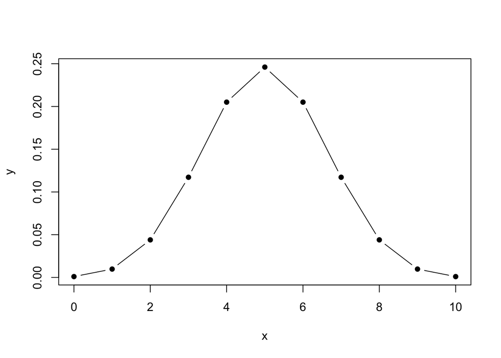

```r
n <- 10
x <- 0:n
y <- dbinom(x,size = n,prob = 0.5)
plot(x,y,type = "b",pch = 16,col="black")
```

#### Cumulative Probability Function

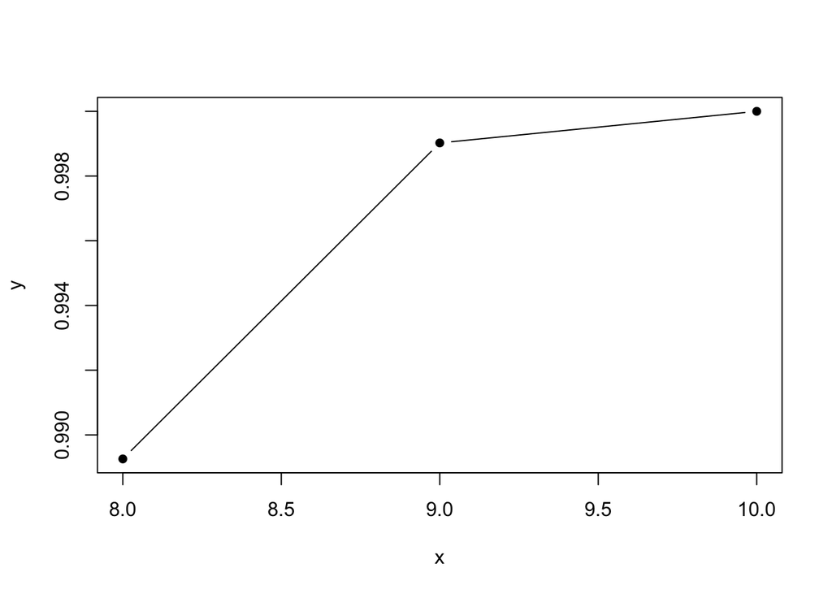

```r
n <- 10
x <- 8:n
y <- pbinom(x,size = n,prob = 0.5)
plot(x,y,type = "b",pch = 16,col="black")
```

# Question 4:

### If cars arrive randomly at a traffic light at the rate of five every ten seconds.

### What the probability that exactly four cars arrive in the next ten seconds?

```r
partone <- dpois(x=4, lambda = 5)
partone
```

```
## [1] 0.1754674
```

### What’s the probability that more than five cars arrive in the next ten seconds?

```r
parttwo <- ppois(q=5, lambda = 5, lower.tail = FALSE)
parttwo
```

```
## [1] 0.3840393
```

### Plot the density function of 0-20 cars arriving in the next ten seconds.

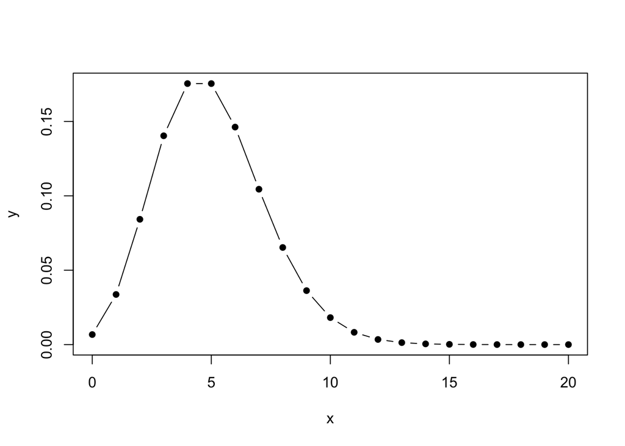

```r
n <- 20
x <- 0:n
y <- dpois(x, lambda = 5)
plot(x,y, type = "b", pch = 16, col = "black")
```